# La cuarentena estricta por sí sola no sirve

Daniel Gervini

7 de septiembre de 2020

## Los casos de Chicago y Buenos Aires

Como ya mencionamos en un [posteo anterior](https://dgervini.github.io/Coronavirus/Historia_dos_ciudades.html), la evolución del coronavirus fue muy diferente en Chicago y en Buenos Aires. El gráfico siguiente muestra la evolución de los casos diarios en las dos ciudades:

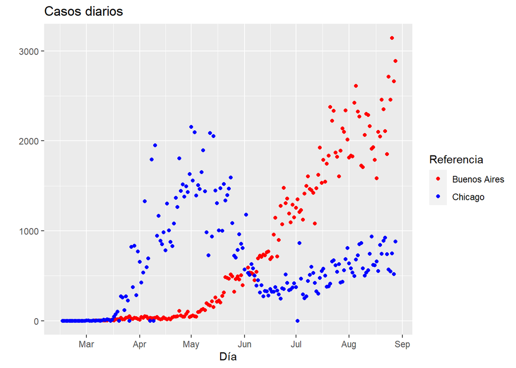

¿Cómo se relaciona esto con las medidas de cuarentena adoptadas por las dos ciudades? En este posteo vamos a mostrar, usando datos de Google Mobility Reports, que la cuarentena fue en realidad mucho más estricta en Buenos Aires que en Chicago, no solo en los papeles sino en el cumplimiento efectivo en la calle.

## Google’s Mobility Reports

Los Community Movility Reports de Google, que pueden encontrarse [acá](https://www.google.com/covid19/mobility/), miden la movilidad de la gente en diferentes lugares de la ciudad usando datos del GPS de los teléfonos celulares y Google Maps. Esto permite medir la disminución efectiva en la circulación pública como respuesta a las medidas de cuarentena o al aislamiento voluntario. Los reportes se dividen en seis categorías: lugares de comercio y recreación, tiendas de comestibles y farmacias, parques y plazas, estaciones de transporte público, lugares de trabajo, y lugares de residencia.

Los reportes informan el porcentaje de cambio con respecto a la base, que se toma como el período entre el 3 de enero y el 6 de febrero de 2020. Para las cinco primeras categorías se mide la cantidad de gente que concurre a los diferentes lugares; para la categoría lugares de residencia, se mide el tiempo que la gente pasa en sus viviendas.

### Lugares de comercio y recreación

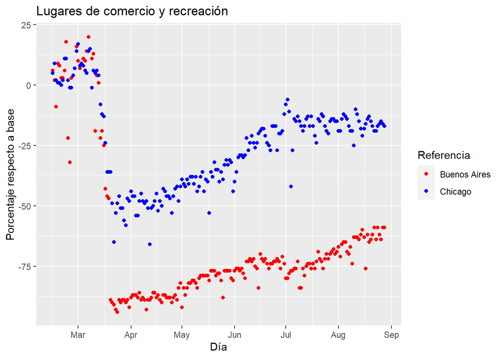

Como se ve, la disminución en la concurrencia a lugares de comercio y recreación fue mucho mayor en Buenos Aires, donde descendió en un 90% entre fines de marzo y mayo, que en Chicago, donde sólo descendió en un 50%. A partir de mayo la concurrencia comenzó a crecer en las dos ciudades, pero siempre manteniéndose muy por debajo en Buenos Aires.

### Tiendas de comestibles y farmacias

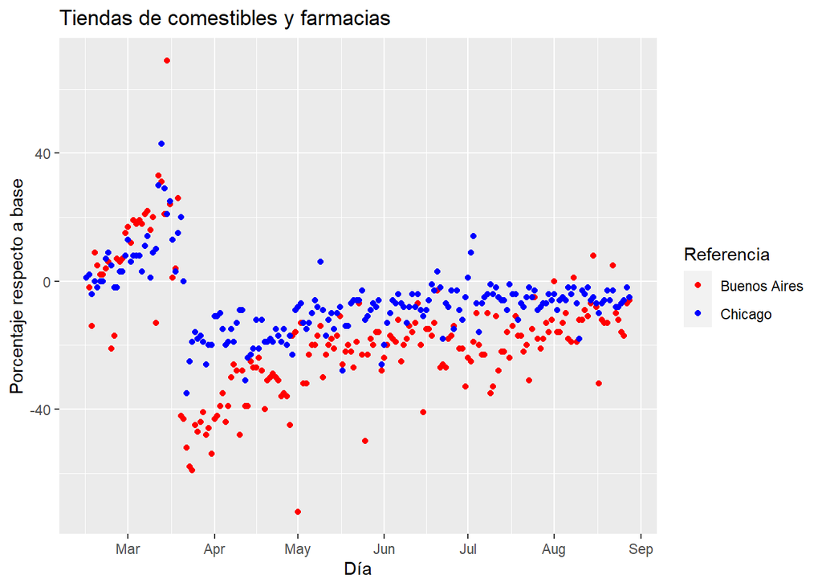

Las tiendas de comestibles y farmacias siempre permanecieron abiertas en las dos ciudades, por lo que las variaciones no fueron tan grandes y la reducción en la concurrencia es comparable en las dos ciudades, aunque siempre fue un poco más marcada en Buenos Aires.

### Parques y plazas

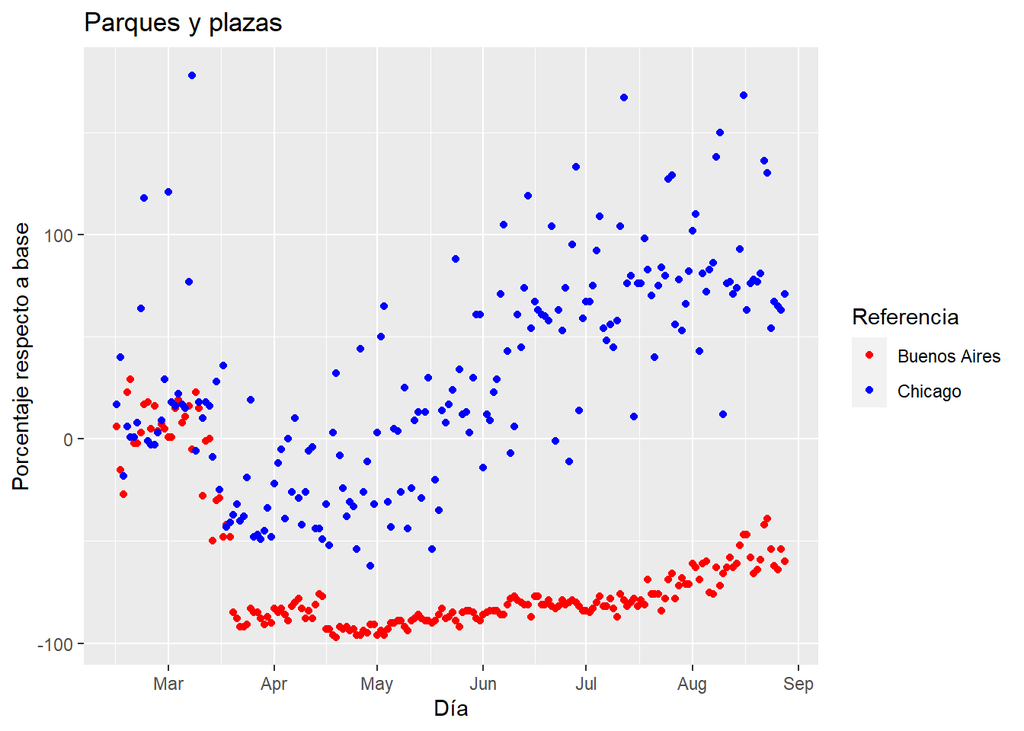

La afluencia a parques y plazas muestra una enorme diferencia entre Buenos Aires y Chicago, porque Chicago nunca cerró la mayoría de sus parques y plazas, ni restringió la libre circulación de las personas. En Buenos Aires, en cambio, parques y plazas permanecieron cerrados hasta fines de julio y la libre circulación en las calles, al menos en teoría, no estaba permitida.

### Estaciones de transporte público

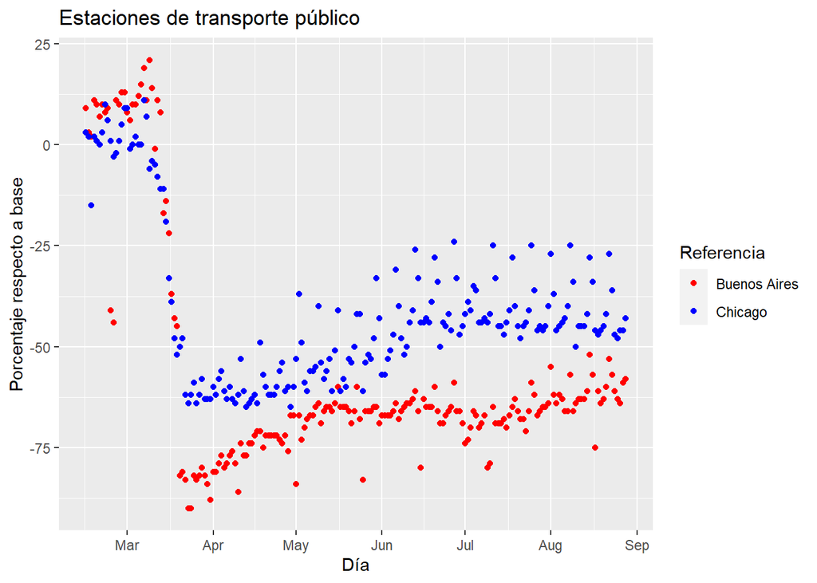

Nuevamente se ve una disminución mucho mayor en el uso del transporte público en Buenos Aires que en Chicago. En Buenos Aires, el uso de transporte público estuvo permitido sólo para trabajadores esenciales. En Chicago nunca se restringió el acceso al transporte público, aunque el uso también disminuyó, en parte por el cierre de lugares de trabajo en abril y mayo y en parte por decisión voluntaria de la gente, ya que desde junio prácticamente todos los comercios y lugares de trabajo están abiertos.

### Lugares de trabajo

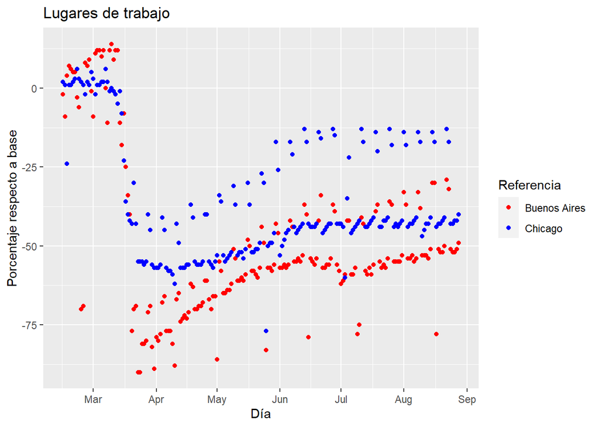

En el gráfico se pueden ver tres líneas distintas para cada ciudad: los fines de semana (línea de arriba), los días laborables de la semana (línea del medio), y los feriados (línea de abajo). Si comparamos línea por línea, vemos que la disminución en la asistencia a lugares de trabajo fue mucho más marcada en Buenos Aires que en Chicago, sobre todo en el mes de abril.

### Lugares de residencia

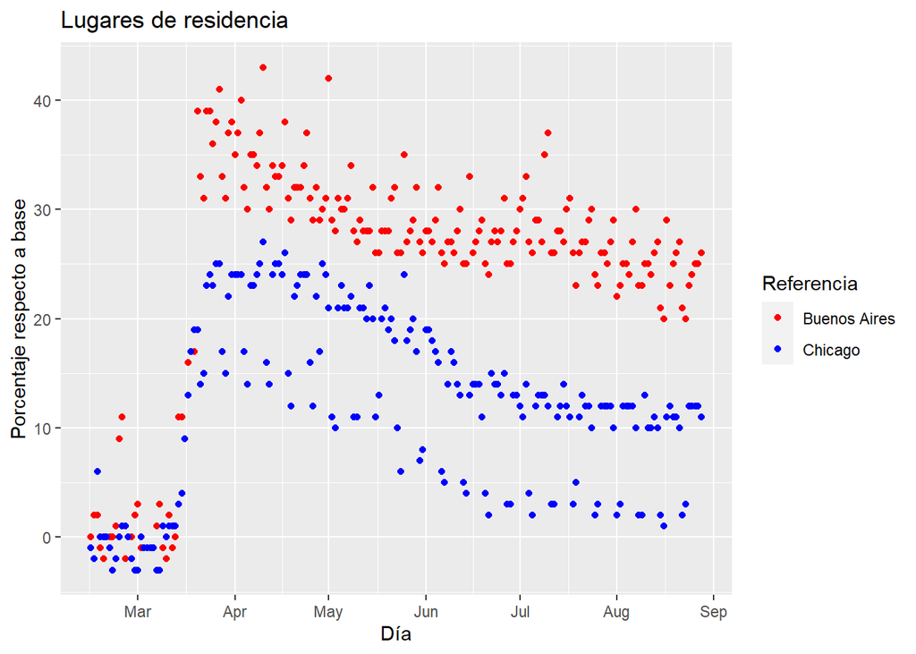

El gráfico muestra que el aumento en la estadía en los hogares fue mucho mayor en Buenos Aires que en Chicago. De hecho, en Chicago se ven dos líneas, correspondientes a los días laborables y los fines de semana, mientras que en Buenos Aires se ve sólo una. Esto se debe a que las salidas recreativas no estuvieron permitidas en Buenos Aires, mientras que sí lo estuvieron en Chicago, donde además los parques y plazas públicas se mantuvieron abiertos y la libre circulación entre ciudades nunca estuvo restringida.

## Conclusiones

Los gráficos anteriores muestran claramente que la cuarentena fue **efectivamente mucho más rígida en Buenos Aires** que en Chicago, no solo en los papeles sino en el cumplimiento de hecho. Por lo tanto, no puede atribuirse a la movilidad pública el hecho de que Buenos Aires no haya logrado bajar el número de reproducción $R_0$ a menos de 1 y lograr así un descenso en la curva de casos diarios en los primeros meses de la cuarentena. Como ya mostramos en [este otro posteo](https://dgervini.github.io/Coronavirus/Quedate_en_casa.html), el $R_0$ depende de otros factores, por ejemplo el nivel de hacinamiento habitacional (que marcó una gran diferencia entre los barrios de Chicago) y la eficacia del sistema de testeos y trazabilidad de contactos.

Algo que sugieren los datos anteriores (aunque se necesitaría un estudio mucho más amplio entre más ciudades para confirmarlo), es que la cuarentena en Buenos Aires **no solo no fue eficaz** para bajar el $R_0$ de manera significativa, sino que incluso **pudo haber sido contraproducente**, al cerrarse parques y plazas públicas y prohibirse las salidas recreativas al aire libre, obligando a mucha gente a permanecer por horas en viviendas hacinadas donde no se puede mantener un distanciamiento físico efectivo.

[Back to blog](https://sites.uwm.edu/gervini/coronavirus-blog/)